# Assignment3_799827

Eric Spinelli

## Problem 1

Si definisce la funzione di partenza

```r
func<-function(x){
  -x^3+4*x^2-2
}
```

Si plotta la funzione per capirne l’andamento

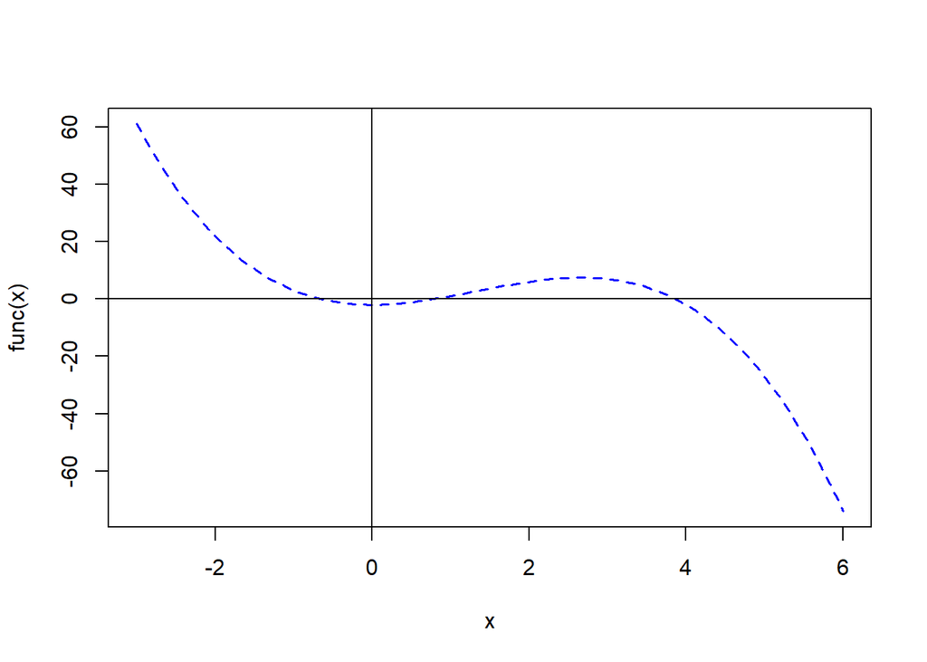

```r
curve(func,xlim=c(-3,6),col='blue',lwd=1.5,lty=2)
abline(h=0)
abline(v=0)
```

Osservando il grafico, si può notare che ci sono tre zeri che è possibile calcolare, uno di questi è in un intorno di 4. Si vuole considerare l’intervallo tra 3 e 4.5 in cui prevede la presenza dello zero considerato.

```r
library(NLRoot)
```

```r
BFfzero(func,3,4.5)
```

```
## [1] 1
## [1] 3.866194
## [1] 5.717732e-05
## [1] "finding root is successful"
```

Si vuole confrontare il risultato con una funzione creata per computare il Bisection Method.

```r
bisection<-function(f,a,b,n=1000,tol=1e-7){
  #f: funzione, a: estremo inferiore, b:estremo superiore,
  #n:iterazioni massime, tol:valore di tolleranza

  #se i segni della funzione nei rispettivi punti a e b è lo stesso,
  #stoppa la funzione e ritorna il messaggio
  if(sign(f(a)==sign(f(b)))){
    stop('f(a) e f(b) devono essere di segno opposto')}

  for(i in 1:n){
    c<-(a+b)/2 #calcolare punto medio

    #se la funzione eguaglia a 0 al punto medio o esso è sotto il livello di tolleranza,
    #la funzione si stoppa e ritorna lo zero
    if((f(c)==0)||((b-a)/2)<tol){ return(c)}

    #se è necessaria un'altra iterazione, controlla il segno della funzione nei due estremi
    #e riassegna a o b a seconda del punto medio
    ifelse(sign(f(c))==sign(f(a)),
           a<-c,
           b<-c)
  }

  #se è raggiunto il massimo numero di iterazioni e non è stato trovato lo zero, la funzione termina
  print('Superato il limite massimo di iterazioni')
}

bisection(func,3,4.5)
```

```
## [1] 3.866198
```

I risultati coincidono: lo zero è localizzato in x = 3.86619

## Problem 2

Considerando la funzione di partenza se ne osserva il grafico. Si può osservare che la figura geometrica prodotta è convessa. Questo vuol dire che gli algoritmi impiegati a computare un minimo, troveranno un minimo globale.

La funzione di partenza è la seguente:
$$f(X_1,X_2) = 2X_1^2 +X_1X_2 +2(X_2-3)^2$$

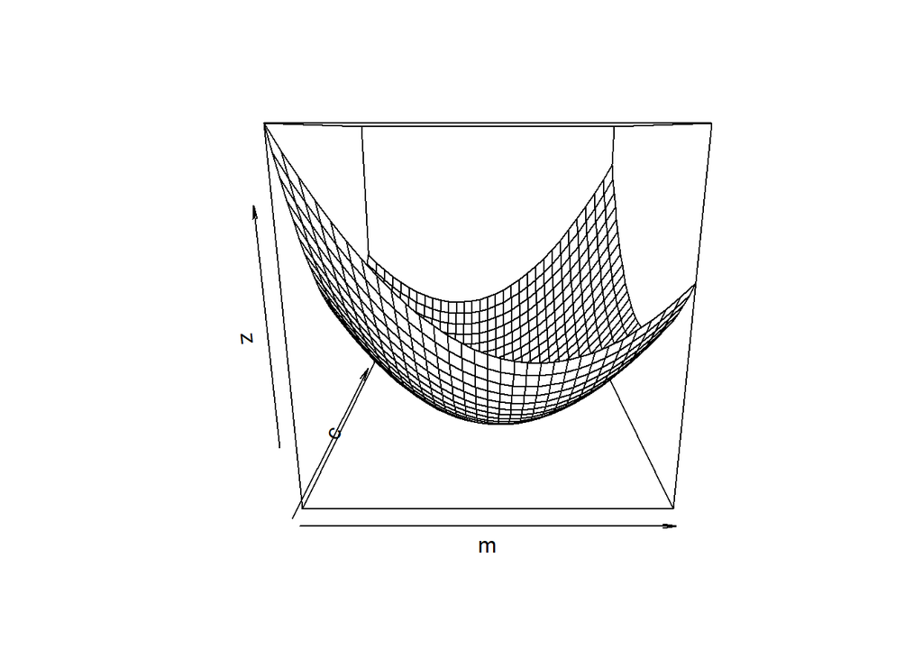

```r
func2<-function(x1,x2){
  2*x1^2+x1*x2+2*(x2-3)^2
}

#si rappresenta il grafico della funzione
m<-seq(-30,30,2)
c<-seq(-30,30,2)
z<-outer(m,c,func2)
persp(m,c,z)
```

### Parte A

Si propone la prima iterazione dell’algoritmo Steepest Descent.

#### 1. Si computa il gradiente della funzione di partenza

Il gradiente della funzione di partenza è
$$\nabla f(x) = [4X_1+X_2, \ X_1+4X_2-12]$$

#### 2. Si computa il gradiente nel punto di partenza

Questo è il primo punto effettivo della prima iterazione.

Il punto di partenza è dato dal problema
$$A=[-1\ \ \ 4]$$

Il gradiente in A si ottiene sostituendo i valori di A (che denomineremo X0) nella formula del gradiente generalizzato, ottenendo il seguente risultato
$$\nabla f(X_0)=[0\ \ \ 3]$$

#### 3. Si confronta la norma del gradiente con il limite di tolleranza

Il limite di tolleranza non è dato dal problema, ma si suppone un limite inferiore a 0.1

Si computa la norma del gradiente (si ignora il termine 0)
$$|| \nabla f(X_0) ||=\sqrt{3^2}=3$$

Il valore ottenuto non rispetta il limite si tolleranza. Se lo rispettasse e ne sarebbe quindi inferiore l’iterazione si fermerebbe qui, in questo caso si prosegue al punto 4.

#### 4. Si aggiorna la direzione del gradiente

La direzione caratterizza il verso del vettore gradiente, positivo quando l’algoritmo è alla ricerca di un massimo, negativo quando è alla ricerca di un minimo.

In questo caso stiamo trattando un problema di minimo, data la convessità della funzione, quindi
$$d_0=- \nabla f(X_0)=[0\ \ \ -3]$$

#### 5. Si aggiorna il punto di partenza con X1

Si computa il nuovo punto di partenza X1 con l’incognita alpha
$$X_1=\begin{bmatrix} -1 \\4 \end{bmatrix} + \alpha_0 \begin{bmatrix} 0 \\-3 \end{bmatrix}=\begin{bmatrix} -1 \\4-3\alpha_0 \end{bmatrix}$$

#### 6. Si determina alpha, quindi si trova X1

Per determinare alpha si sostituiscono i valori di X1 con l’incognita nella funzione iniziale
$$f(X_1,X_2)=2(-1)^2+(-1)(4-3\alpha_0)+2((4-3\alpha_0)-3)^2$$

che dopo aver eseguito tutti i passaggi risulta
$$f(X_1,X_2)=18\alpha_0^2-9\alpha_0$$

Di questo risultato si computa la derivata prima e si risolve l’equazione di primo grado per alpha
$$f^{'}(X_1,X_2)=36\alpha_0-9=0$$
quindi alpha=0.25, da cui si risolve X1
$$X_1=\begin{bmatrix} -1 \\3.25 \end{bmatrix}$$
Qui termina la prima iterazione dell’algoritmo.

#### 7. Si computa il gradiente in X1

Si sostituiscono quindi i valori di X1 nella formula del gradiente generalizzato trovato in precedenza
$$\nabla f(X_1)=[-0.75\ \ \ 0]$$

#### 8. Si confronta la norma del gradiente con il limite di tolleranza

Si computa la norma del gradiente (si ignora il termine 0)
$$||\nabla f(X_1)||=\sqrt{(-0.75)^2}=0.75$$
Il risultato è un valore superiore al limite proposto di 0.1, quindi si dovrebbe procedere con le iterazioni fin quando la norma del gradiente rispetto al punto Xn non soddisfi la condizione dettata dal limite di tolleranza

### Parte B

Si prende in considerazione il punto di partenza A=[-1 4] e si esegue un’iterazione con il metodo di Newton.

#### 1. Si computa il gradiente della funzione

Il gradiente della funzione di partenza è
$$\nabla f(x) = [4X_1+X_2, \ X_1+4X_2-12]$$

#### 2. Si computa la matrice Hessiana rispetto al gradiente

La matrice Hessiana è formulata in questo modo
$$Hf(X)=\begin{bmatrix} \frac{\Delta^2f(x)}{\Delta x_1^2} & \frac{\Delta^2f(x)}{\Delta x_1 \Delta x_2} \\\frac{\Delta^2f(x)}{\Delta x_1 \Delta x_2} & \frac{\Delta^2f(x)}{\Delta x_2^2} \end{bmatrix}$$

se ne computano quindi i valori rispetto alle derivate caratterizzanti della matrice, ottenendo il seguente risultato
$$Hf(X)=\begin{bmatrix} 4 & 1 \\1 & 4 \end{bmatrix}$$

#### 3. Si computa la matrice inversa dell’Hessiana

Svolgendo le operazioni manualmente si può utilizzare il metodo dei cofattori. Il risultato finale è qui verificato

```r
#riportiamo i risultati della matrice Hessiana
H<-matrix(c(4,1,1,4),ncol=2)

#matrice inversa dell'Hessiana
Inv_H<-solve(H)
```

Quindi l’inversa dell’Hessiana è
$$H^{-1}f(X)=\begin{bmatrix} 4/15 & -1/15 \\-1/15 & 4/15 \end{bmatrix}$$

#### 4. Si computa il gradiente per A

Si sostituiscono i valori del gradiente generalizzato computato al punto 1 e si sostituiscono i valori del punto di partenza A (indicato con X0), ottenendo
$$\nabla f(X_0)=[0\ \ \ 3]$$

#### 5. Si computa il nuovo punto X1

Il nuovo punto X1 si computa nel seguente modo
$$X_1=X_0-H^{-1}f(X_0)\nabla f(X_0)=\begin{bmatrix} -1 \\4 \end{bmatrix}-\begin{bmatrix} 4/15 & -1/15 \\-1/15 & 4/15 \end{bmatrix} \begin{bmatrix} 0 \\3 \end{bmatrix}$$

Si ottiene quindi il risultato
$$X_1=\begin{bmatrix} -0.79 \\3.19 \end{bmatrix}$$

#### 6. Si computa il gradiente di X1

Si sostituisce i valori di X1 nella formula del gradiente generalizzato
$$\nabla f(X_1)=[0.03\ \ \ -0.03]$$

Si può notare che il gradiente in X1 è approssimabile a zero, il che significa che l’algoritmo ha trovato il minimo globale in questo caso, trattandosi di una funzione convessa

### Parte C

Se la matrice Hessiana della funzione è definita positiva allora sarà sufficiente un’unica iterazione per la funzione quadratica per raggiungere il punto ottimale da qualunque punto di partenza.

Essere definita positiva significa che la sua forma quadratica è positiva per qualunque x diverso da 0.
$$x^TAx >0$$

## Problem 3

L’algoritmo Simulated Annealing è utile ad approssimare l’ottimo globale di una funzione

Si vuole innanzi tutto avere una rappresentazione della funzione di partenza per capirne l’andamento generale

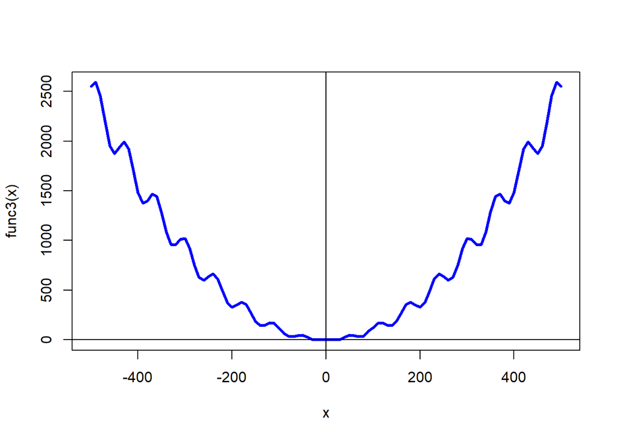

```r
func3<-function(x){
  34*exp(-0.5*((x-88)/2)^2)+((x/10)-2*sin(x/10))^2
}

#rappresentazione della curva
curve(func3, xlim=c(-500,500), col='blue', lwd=3)
abline(h=0)
abline(v=0)
```

Una prima osservazione è che evidentemente esistono molteplici minimi locali, ma la forma della funzione ci lascia presumere che esista un minimo globale.

Si vuole avere un’idea più chiara della funzione nell’intorno di 0, quindi si ingrandisce il grafico nell’intervallo -20, 20 per studiare l’andamento della funzione in questo intorno.

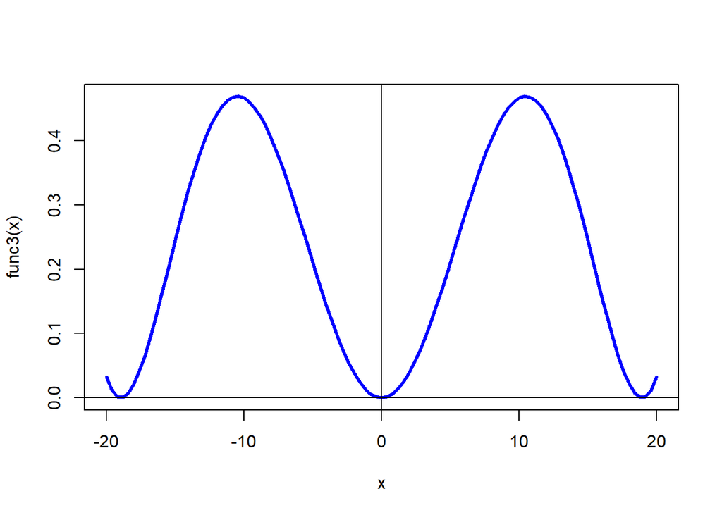

```r
curve(func3, xlim=c(-20,20), col='blue', lwd=3)
abline(h=0)
abline(v=0)
```

Si ha un sospetto rispetto all’ipotesi che in 0 esista un unico minimo globale, poichè sembrerebbe che la funzione assuma il medesimo valore in ordinate prossime a -20 e 20. Si procede quindi ad una verifica.

Si decide di computare il minimo globale con la funzione GenSA, dall’omonimo pacchetto

```r
#si sceglie di utilizzare la funzione GenSA
library(GenSA)
```

Dopo alcuni tentativi empirici, si sceglie l’intervallo da prendere in considerazione:

```r
#si decide di aumentare il numero massimo delle iterazioni data
#la complessità della funzione
gensa<-GenSA(fn=func3,lower = -250,upper = 250,control=list(maxit=50000))
```

Il risultato della funzione indica che il minimo globale della funzione è localizzato nel punto di coordinate [0,0]

```r
print(paste('ascissa del minimo Globale:',gensa$par))
```

```
## [1] "ascissa del minimo Globale: 3.53200541730603e-15"
```

```r
print(paste('ordinata del minimo Globale:',gensa$value))
```

```
## [1] "ordinata del minimo Globale: 1.24750622678791e-31"
```

Si analizzano ora gli altri 2 punti sospetti

```r
#si considera la funzione GenSA in un intorno di 20
ord1<-GenSA(fn=func3,lower = 15,upper = 25)$value
asc1<-GenSA(fn=func3,lower = 15,upper = 25)$par
```

```r
#si considera la funzione GenSA in un intorno di -20
ord2<-GenSA(fn=func3,lower = -25,upper = -15)$value
asc2<-GenSA(fn=func3,lower = -25,upper = -15)$par
```

Si verifica se nei punti di ottimo degli intorni considerati la funzione assume valori più grandi rispetto al valore nel punto [0,0]. Se i valori saranno più grandi (rispetto all’asse delle ordinate), si può affermare che in 0 vi è effettivamente un minimo globale

```r
#minimo locale nell'intorno di 20
print(paste("ascissa minimo locale:",asc1))
```

```
## [1] "ascissa minimo locale: 18.9549426704409"
```

```r
print(paste("ordinata minimo locale:",ord1))
```

```
## [1] "ordinata minimo locale: 2.73971783658266e-22"
```

Il valore dell’ordinata è leggermente più grande che in zero

```r
#minimo locale nell'intorno di -20
print(paste("ascissa minimo locale:",asc2))
```

```
## [1] "ascissa minimo locale: -18.9549426704048"
```

```r
print(paste("ordinata minimo locale:",ord2))
```

```
## [1] "ordinata minimo locale: 1.13345251078358e-22"
```

Il valore dell’ordinata è leggermente più grande che in zero.

Si conferma quindi che in [0,0] vi è il minimo globale, computato correttametne dall’algoritmo.